# Practical Machine Learning Project - Human Activity Recognition

Manfredi Ruggeri

5/11/2021

### Summary

In the last years a large amount of data about personal activity was collected by wereable sensors; analyzing resulting datasets can be useful in order to classify not only the type of executed movement but also the quality of performance.  
This project has the purpose of developing a machine learning algorithm to predict how (well) a specific activity was executed.

Used dataset is from:  
Velloso, E.; Bulling, A.; Gellersen, H.; Ugulino, W.; Fuks, H. Qualitative Activity Recognition of Weight Lifting Exercises. Proceedings of 4th International Conference in Cooperation with SIGCHI (Augmented Human ’13) . Stuttgart, Germany: ACM SIGCHI, 2013.

### Getting and cleaning Data

Load Libraries

```r
library(caret)
library(ggplot2)
library(rattle)
```

Load Dataset

```r
df <- read.csv("pml-training.csv", na.strings = c("NA","","#DIV/0!"))
valid <- read.csv("pml-testing.csv", na.strings = c("NA","","#DIV/0!"))
dim(df)
```

```
## [1] 19622   160
```

In some variables we can see a huge presence of NA values (more than 90%) so we proceed to delete them; furthermore we delete those variables that refer to quantities we are not interested in.

```r
df <- df[, -c(1:7)]
tb <- apply(df, 2, function(x) sum(is.na(x)/dim(df)[1])> 0.9)
df <- df[, tb == FALSE]
dim(df)
```

```
## [1] 19622    53
```

### Building Machine Learning Models

Splitting dataset in train and test

```r
inTrain = createDataPartition(df$classe, p = 3/4, list=FALSE)
training = df[ inTrain,]
testing = df[-inTrain,]
set.seed(7373)
```

The variable we are interested in is classe

```r
table(training$classe)
```

```
##
##    A    B    C    D    E
## 4185 2848 2567 2412 2706
```

we can see that classe has only five characters, representing the quality of executed movement. It seems reasonable to use a classification algorithm like decision tree and according to results, perform other and more sophisticated algorithms.

**Decision Tree Model**

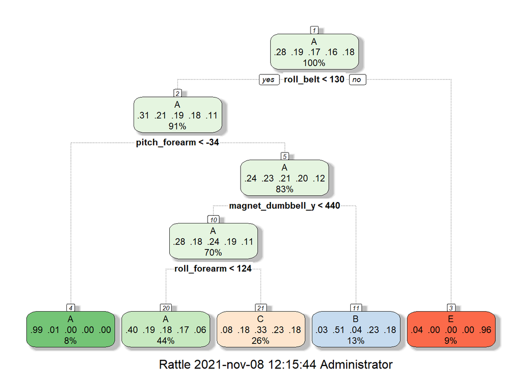

```r
set.seed(7373)
treeModel <- train(classe ~ . , method='rpart', data = training)
fancyRpartPlot(treeModel$finalModel)
```

```r
testing$classe <- as.factor(testing$classe)
treeModelPredict <- predict(treeModel, newdata = testing)
confMatrixTreeModel <- confusionMatrix(treeModelPredict, testing$classe)
print(confMatrixTreeModel$table)
```

```
##           Reference
## Prediction    A    B    C    D    E
##          A 1249  379  397  349  113
##          B   24  337   27  141  130
##          C   99  233  431  314  244
##          D    0    0    0    0    0
##          E   23    0    0    0  414
```

```r
print(confMatrixTreeModel$overall[1])
```

```
##  Accuracy
## 0.4957178
```

Unfortunately, an accuracy equals to 49% isn’t enough

**Generalized Boosted Model**

```r
gbmModel  <- train(classe ~ ., data = training, method = "gbm", verbose=FALSE)
gbmPredict <- predict(gbmModel, newdata = testing)
confMatrixGbmModel <- confusionMatrix(gbmPredict, testing$classe)
print(confMatrixGbmModel)
```

```
## Confusion Matrix and Statistics
##
##           Reference
## Prediction    A    B    C    D    E
##          A 1369   30    0    3    1
##          B   16  899   31    2   12
##          C    6   20  810   32   10
##          D    2    0   13  762   14
##          E    2    0    1    5  864
##
## Overall Statistics
##
##                Accuracy : 0.9592
##                  95% CI : (0.9533, 0.9646)
##     No Information Rate : 0.2845
##     P-Value [Acc > NIR] : < 2.2e-16
##
##                   Kappa : 0.9484
##
##  Mcnemar's Test P-Value : 1.02e-06
##
## Statistics by Class:
##
##                      Class: A Class: B Class: C Class: D Class: E
## Sensitivity            0.9814   0.9473   0.9474   0.9478   0.9589
## Specificity            0.9903   0.9846   0.9832   0.9929   0.9980
## Pos Pred Value         0.9758   0.9365   0.9226   0.9633   0.9908
## Neg Pred Value         0.9926   0.9873   0.9888   0.9898   0.9908
## Prevalence             0.2845   0.1935   0.1743   0.1639   0.1837
## Detection Rate         0.2792   0.1833   0.1652   0.1554   0.1762
## Detection Prevalence   0.2861   0.1958   0.1790   0.1613   0.1778
## Balanced Accuracy      0.9858   0.9659   0.9653   0.9703   0.9785
```

```r
# print(confMatrixGbmModel$overall[1])
```

With generalized boosted method we get:

```r
print(confMatrixGbmModel$overall[1])
```

```
## Accuracy
## 0.959217
```

a very good value.

**Random Forest Model**

```r
rfModel <- train(classe ~ ., data = training, method = "rf", verbose = FALSE)
print(rfModel$finalModel)
```

```
##
## Call:
##  randomForest(x = x, y = y, mtry = min(param$mtry, ncol(x)), verbose = FALSE)
##                Type of random forest: classification
##                      Number of trees: 500
## No. of variables tried at each split: 27
##
##         OOB estimate of  error rate: 0.58%
## Confusion matrix:
##      A    B    C    D    E class.error
## A 4179    4    2    0    0 0.001433692
## B   20 2821    7    0    0 0.009480337
## C    0    9 2548   10    0 0.007401636
## D    0    0   23 2387    2 0.010364842
## E    0    0    5    3 2698 0.002956393
```

```r
rfPredict <- predict(rfModel, newdata = testing)
confMatrixRf <- confusionMatrix(rfPredict, testing$classe)
print(confMatrixRf)
```

```
## Confusion Matrix and Statistics
##
##           Reference
## Prediction    A    B    C    D    E
##          A 1394    4    0    0    0
##          B    0  942    4    0    1
##          C    0    3  847   13    2
##          D    0    0    4  791    4
##          E    1    0    0    0  894
##
## Overall Statistics
##
##                Accuracy : 0.9927
##                  95% CI : (0.9899, 0.9949)
##     No Information Rate : 0.2845
##     P-Value [Acc > NIR] : < 2.2e-16
##
##                   Kappa : 0.9907
##
##  Mcnemar's Test P-Value : NA
##
## Statistics by Class:
##
##                      Class: A Class: B Class: C Class: D Class: E
## Sensitivity            0.9993   0.9926   0.9906   0.9838   0.9922
## Specificity            0.9989   0.9987   0.9956   0.9980   0.9998
## Pos Pred Value         0.9971   0.9947   0.9792   0.9900   0.9989
## Neg Pred Value         0.9997   0.9982   0.9980   0.9968   0.9983
## Prevalence             0.2845   0.1935   0.1743   0.1639   0.1837
## Detection Rate         0.2843   0.1921   0.1727   0.1613   0.1823
## Detection Prevalence   0.2851   0.1931   0.1764   0.1629   0.1825
## Balanced Accuracy      0.9991   0.9957   0.9931   0.9909   0.9960
```

After a very expensive computation, with Random Forest we achieve an accuracy of:

```r
print(confMatrixRf$overall[1])
```

```
##  Accuracy
## 0.9926591
```

We choose Random Forest to predict validation dataset.

```r
predictValid <- predict(rfModel, newdata = valid)
print(predictValid)
```

```
##  [1] B A B A A E D B A A B C B A E E A B B B
## Levels: A B C D E
```

### Conclusions

In this example, machine learning based on random forest algorithm achieved the best accuracy; although it was computationally expensive in terms of time and resources, it could optimistically achieve a high precise model in order to predict how (well) any physical activity is performed.